# Analysis of Tooth Growth

Sid Reddy

December 20, 2014

## Exploratory data analysis

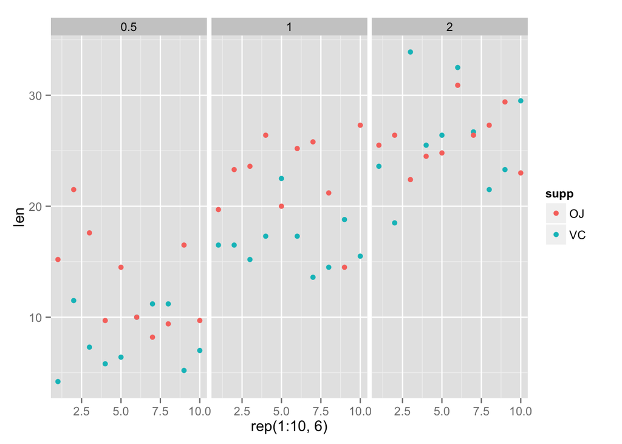

```r
library(datasets)
library(ggplot2)

data(ToothGrowth)
ggplot(ToothGrowth) + geom_point(aes(x = rep(1:10, 6), y = len, color = supp)) + facet_grid( ~ dose)
```

Another plot shows the effect of dose, for each of VC and OJ. For OJ, the difference between 1mg vs 2mg appears minimal, while for VC 2mg is a clear winner. For both VC and OJ, 0.5mg is insufficient.

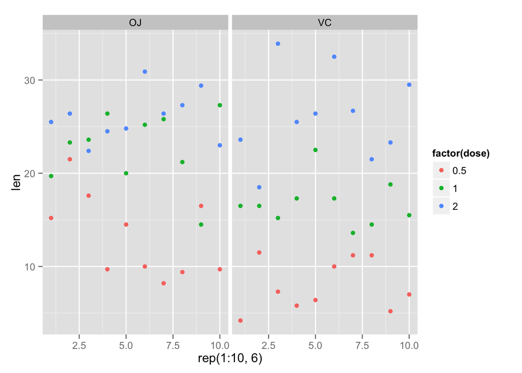

```r
ggplot(ToothGrowth) + geom_point(aes(x = rep(1:10, 6), y = len, color = factor(dose))) + facet_grid( ~ supp)
```

## Basic summary of data

The table below shows the mean and the standard deviation for each combination of supplement and dose values. We notice that only OJ at 1 and 2mg, and VC at 2mg are the major contenders for boosting tooth growth in guinea pigs.

```r
library(dplyr)
library(reshape2)
library(knitr)
s <- summarize(group_by(ToothGrowth, supp, dose), 'mean, sd' = paste(mean(len), round(sd(len), 2), sep = ', '))
t <- dcast(s, supp ~ dose, value.var = "mean, sd")
kable(t, caption = 'Mean and standard deviation for each (supp, dose) combination')
```

Mean and standard deviation for each (supp, dose) combination

| supp | 0.5 | 1 | 2 |
| --- | --- | --- | --- |
| OJ | 13.23, 4.46 | 22.7, 3.91 | 26.06, 2.66 |
| VC | 7.98, 2.75 | 16.77, 2.52 | 26.14, 4.8 |

## Hypothesis testing

There are three combinations we can test like we discussed above: OJ at 1, 2mg, and VC at 2mg. First, let’s consider OJ and VC at 2mg.

```r
d1 <- unlist(select(filter(ToothGrowth, supp == 'OJ', dose == 2), len))
d2 <- unlist(select(filter(ToothGrowth, supp == 'VC', dose == 2), len))
d3 <- unlist(select(filter(ToothGrowth, supp == 'OJ', dose == 1), len))

rbind(
  t.test(d1, d2)$conf, # Compare OJ at 2mg with VC at 2mg
  t.test(d1, d3)$conf, # Compare OJ at 2mg with OJ at 1mg
  t.test(d2, d3)$conf # Compare VC at 2mg with OJ at 1mg
)
```

```
##            [,1]     [,2]
## [1,] -3.7980705 3.638070
## [2,]  0.1885575 6.531443
## [3,] -0.6843336 7.564334
```

There is a clear difference between OJ at 2mg vs 1mg (the 95% confidence interval does not contain 0), so we can eliminate OJ at 1mg. Note that while VC at 2mg is not clearly better than OJ at 1mg with 95% confidence, we can conclude that with 90% confidence as shown below.

```r
t.test(d2, d3, conf.level = 0.9)$conf
```

```
## [1] 0.03827356 6.84172644
## attr(,"conf.level")
## [1] 0.9
```

Let’s analyze OJ vs VC at 2mg a little more. We notice that even with 50% confidence, we cannot make a clear separation between the results. Thus, the conclusion is that both OJ or VC work equally well at 2mg for the best tooth growth.

```r
t.test(d1, d2, conf.level = 0.5)$conf
```

```
## [1] -1.280561  1.120561
## attr(,"conf.level")
## [1] 0.5
```

Let’s now make a few other comparisons, and we will obtain a descending order wrt tooth growth of the supplement and dose values.

```r
d4 <- unlist(select(filter(ToothGrowth, supp == 'VC', dose == 1), len))
d5 <- unlist(select(filter(ToothGrowth, supp == 'OJ', dose == 0.5), len))
d6 <- unlist(select(filter(ToothGrowth, supp == 'VC', dose == 0.5), len))

rbind(
  t.test(d3, d4)$conf, # OJ vs VC at 1mg
  t.test(d3, d5)$conf, # OJ at 1mg vs 0.5mg
  t.test(d4, d5)$conf, # VC at 1mg vs OJ at 0.5mg
  t.test(d5, d6)$conf, # OJ at 0.5mg vs VC at 0.5mg
  t.test(d4, d6)$conf  # VC at 1mg vs 0.5mg
)
```

```
##            [,1]      [,2]
## [1,] 2.80214825  9.057852
## [2,] 5.52436564 13.415634
## [3,] 0.07189097  7.008109
## [4,] 1.71905727  8.780943
## [5,] 6.31428796 11.265712
```

From the t-tests above, the descending order is: * OJ or VC at 2mg * OJ at 1mg * VC at 1mg * OJ at 0.5mg * VC at 0.5mg

## Conclusions and assumptions

Conclusions:

- For best tooth growth, you can use either orange juice (OJ) or ascorbic acid (VC) with a 2mg dose.
- Orange juice is better than ascorbic acid at dose levels of 0.5mg and 1mg.
- For both OJ and VC, a higher dose is strictly better (2mg > 1mg > 0.5mg).